# FigureYa222PCAgene_Simplified

**Author(s)**: Zongcheng Li **Reviewer(s)**: Ying Ge, Yijing Chen **Date**: 2025-11-28

## 1 Academic Citation

If you use this code in your work or research, we kindly request that you cite our publication:

Xiaofan Lu, et al. (2025). FigureYa: A Standardized Visualization Framework for Enhancing Biomedical Data Interpretation and Research Efficiency. iMetaMed. https://doi.org/10.1002/imm3.70005

## 2 需求描述 Requirement description

这个PCA很特别

This PCA is quite special.

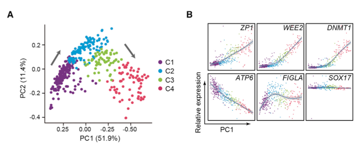

From https://linkinghub.elsevier.com/retrieve/pii/S0092867420300568

Figure 3. Dynamic Gene-Expression Patterns of Oocyte Subtypes at Stepwise Developmental Stages (A) PCA plot showing four oocyte subtypes based on gene-expression patterns exhibited by PC1 and PC2. (B) Relative gene-expression patterns of representative genes essential for oocyte development along the PC1 dimension.

## 3 应用场景 Application scenarios

单细胞RNA-seq，从PCA结果就能看出基因表达模式跟细胞类型的关系。

原文：Principal component analysis (PCA) revealed that the four oocyte subtypes were distributed along the principal component 1 (PC1) dimension (Figure 3A; Table S2).

Consistently, the relative expression levels of **genes known to be essential for follicular development also varied along PC1 axis** (Figures 3B and S3A). Genes promoting follicle development, such as ZP1, BMP15, and GDF9, were progressively **upregulated from oocyte subtype C1 to C4**. Meiotic M phase genes WEE2 and AURKA as well as DNA methyltransferase, DNMT1 and DNMT3A, were also gradually upregulated from subtype C1 to C4 (Figures 3B and S3A).

Single-cell RNA-seq, the relationship between gene expression patterns and cell types can be discerned directly from the PCA results.

Original text: Principal component analysis (PCA) revealed that the four oocyte subtypes were distributed along the principal component 1 (PC1) dimension (Figure 3A; Table S2).

Consistently, the relative expression levels of **genes known to be essential for follicular development also varied along PC1 axis** (Figures 3B and S3A). Genes promoting follicle development, such as ZP1, BMP15, and GDF9, were progressively **upregulated from oocyte subtype C1 to C4**. Meiotic M phase genes WEE2 and AURKA as well as DNA methyltransferase, DNMT1 and DNMT3A, were also gradually upregulated from subtype C1 to C4 (Figures 3B and S3A).

## 4 环境设置 Environment Setting

```r
source("install_dependencies.R")
```

```
## Starting R package installation...
## ===========================================
##
## Installing Bioconductor packages...
## Package already installed: batchelor
##
## Installing CRAN packages...
## Package already installed: Seurat
## Package already installed: ggplot2
## Package already installed: magrittr
##
## ===========================================
## Package installation completed!
## You can now run your R scripts in this directory.
```

```r
library(Seurat) # 单细胞RNA-seq分析工具 Single-cell RNA-seq analysis tool
```

```r
library(magrittr) # 管道操作符 Pipe operator
library(ggplot2) # 绘图工具 Plotting tool
library(stats) # 用于 kmeans 聚类 for kmeans clustering
Sys.setenv(LANGUAGE = "en") # 显示英文报错信息 Show English error messages
options(stringsAsFactors = FALSE) # 禁止chr转成factor Prevent character-to-factor conversion
```

## 5 输入文件 Input files

sc.seurat_v5.Rdata，单细胞RNA-seq预处理获得的文件，出自FigureYa206scHeatmap

怎样获得这个文件？拖到文末看”附：单细胞RNA-seq数据预处理”

sc.seurat_v5.Rdata, the file obtained from single-cell RNA-seq preprocessing. It originates from FigureYa206scHeatmap.

How to obtain this file? Scroll to the end of the document and see “Appendix: Single-cell RNA-seq Data Preprocessing”

```r
(load("sc.seurat_v5.Rdata"))
```

```
## [1] "sc"             "cluster_colors"
```

## 6 PCA

### 6.1 原文采用的聚类方法 The clustering method employed in the original text

例文的非监督聚类方法比较特殊，以SCENIC的分析结果作为输入（SCENIC的用法可参考FigureYa194pySCENIC），用modified ‘clustering-and-classification’ algorithm (Lake et al., 2016) 给细胞做聚类。clustering-and-classification也是个很有趣的半监督聚类算法。

The unsupervised clustering method used in the example text is quite unique, taking the analysis results from SCENIC as input (for the usage of SCENIC, you can refer to FigureYa194pySCENIC), and applying modified ‘clustering-and-classification’ algorithm (Lake et al., 2016) to cluster the cells. The clustering-and-classification is also an interesting semi-supervised clustering algorithm.

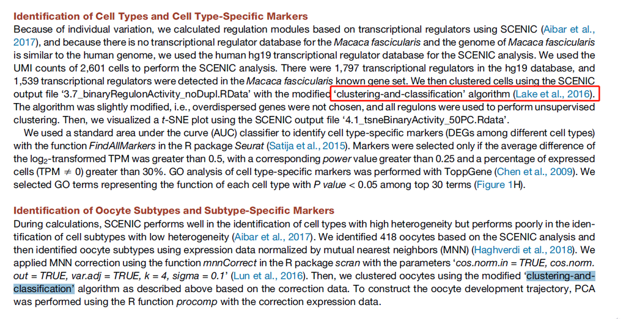

### 6.2 我们用Seurat自带的无监督聚类 We employ Seurat’s built-in unsupervised clustering

```r
## 提取oocytes subtype的细胞的数据
# 从文章附件获得oocytes subtype的细胞ID（191 young oocytes, 227 old oocytes）
# 这里用到第一列cell ID，用于提取oocytes subtype的细胞
## Extract data for oocyte subtype cells
# Obtain cell IDs for oocyte subtypes from article attachments (191 young oocytes, 227 old oocytes)
# Utilise the first column cell ID to extract cells for oocyte subtypes
meta_oo <- readxl::read_excel(path = "1-s2.0-S0092867420300568-mmc2.xlsx", sheet = 2)
sc_oo <- sc[, meta_oo$cell] # only 414 (not 418?! ) cells in the metadata

## 自己的数据，就不涉及取子集，直接用sc就好，用下面这行代替上面两行：
## For your own data, there's no need to take a subset; you can directly use sc, replace the two lines above with the following:
# sc_oo <- sc

# Simplified approach similar to v4: no complex mnnCorrect, just use standard Seurat workflow
# 简化方法，类似v4版本：不使用复杂的mnnCorrect，直接使用标准Seurat流程
sc_oo <- sc_oo

# HVGs (similar to v4)
#sc_oo %<>% FindVariableFeatures(selection.method = "mvp", mean.cutoff = c(1,8))
sc_oo %<>% FindVariableFeatures(selection.method = "vst")
```

```
## Finding variable features for layer counts
```

```r
VariableFeatures(sc_oo) %>% length()
```

```
## [1] 2000
```

```r
# Run standard Seurat workflow (similar to v4)
# 运行标准Seurat流程（类似v4版本）
sc_oo %<>% ScaleData
sc_oo %<>% RunPCA
```

[output not shown]

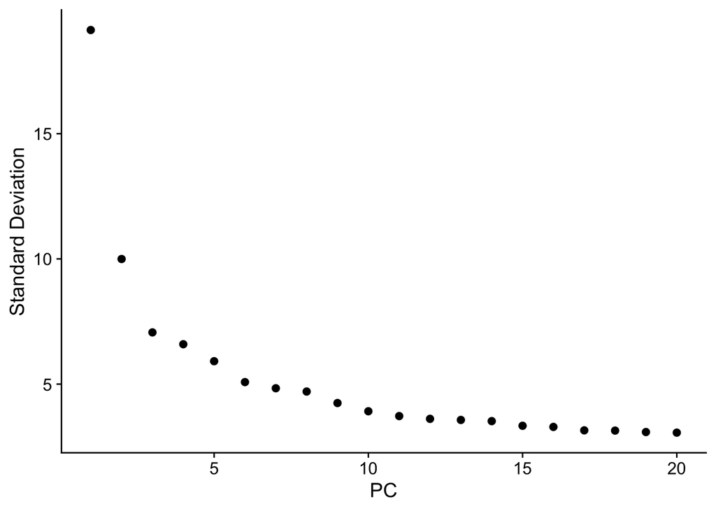

```r
ElbowPlot(sc_oo)
```

```r
# Try different approaches to get exactly 4 clusters
# 尝试不同方法来获得恰好4个聚类
cat("Attempting different clustering parameters...\n")
```

```
## Attempting different clustering parameters...
```

```r
# Method 1: Standard clustering approach first
# 方法1：首先使用标准聚类方法
sc_oo <- FindNeighbors(sc_oo, dims = 1:15)
sc_oo <- FindClusters(sc_oo, resolution = 0.6)
```

```
## Modularity Optimizer version 1.3.0 by Ludo Waltman and Nees Jan van Eck
##
## Number of nodes: 414
## Number of edges: 9159
##
## Running Louvain algorithm...
## Maximum modularity in 10 random starts: 0.8623
## Number of communities: 8
## Elapsed time: 0 seconds
```

```r
# Check current clusters
# 检查当前聚类数量
n_clusters <- length(unique(sc_oo$seurat_clusters))
cat("Number of clusters found with resolution 0.6:", n_clusters, "\n")
```

```
## Number of clusters found with resolution 0.6: 8
```

```r
# Method 2: If not 4 clusters, adjust resolution
# 方法2：如果不是4个聚类，调整resolution
if (n_clusters != 4) {
  cat("Adjusting resolution to get exactly 4 clusters...\n")
  for (res in seq(0.1, 2.0, by = 0.1)) {
    cat("Trying resolution:", res, "\n")
    sc_oo_temp <- FindNeighbors(sc_oo, dims = 1:15)
    sc_oo_temp <- FindClusters(sc_oo_temp, resolution = res)
    n_temp_clusters <- length(unique(sc_oo_temp$seurat_clusters))
    cat("Number of clusters found:", n_temp_clusters, "\n")

    if (n_temp_clusters == 4) {
      sc_oo <- sc_oo_temp
      cat("Found optimal resolution:", res, "with exactly 4 clusters\n")
      break
    }
  }
}
```

```
## Adjusting resolution to get exactly 4 clusters...
## Trying resolution: 0.1
```

```
## Modularity Optimizer version 1.3.0 by Ludo Waltman and Nees Jan van Eck
##
## Number of nodes: 414
## Number of edges: 9159
##
## Running Louvain algorithm...
## Maximum modularity in 10 random starts: 0.9493
## Number of communities: 4
## Elapsed time: 0 seconds
## Number of clusters found: 4
## Found optimal resolution: 0.1 with exactly 4 clusters
```

```r
# Final check and force if needed
# 最终检查，如果需要则强制
final_n_clusters <- length(unique(sc_oo$seurat_clusters))
cat("Final number of clusters:", final_n_clusters, "\n")
```

```
## Final number of clusters: 4
```

```r
if (final_n_clusters != 4) {
  cat("Warning: Could not get exactly 4 clusters. Using alternative approach...\n")
  # Alternative: Use k-means on PCA results to force 4 clusters
  # 备选方案：在PCA结果上使用k-means强制4个聚类
  pca_embeddings <- sc_oo@reductions$pca@cell.embeddings[, 1:2]
  set.seed(123) # for reproducibility
  kmeans_result <- kmeans(pca_embeddings, centers = 4)
  sc_oo$seurat_clusters <- factor(kmeans_result$cluster, labels = paste0("C", 1:4))
  cat("Used k-means on PCA embeddings to force 4 clusters\n")
}

# Get PCA results
# 获取PCA结果
pca.pv <- sc_oo@reductions$pca
# 每个基因的主成分
# The principal component of each gene
# pca.pv@feature.loadings
dim(pca.pv@feature.loadings)
```

```
## [1] 2000   50
```

## 7 开始画图 Start drawing

### 7.1 画Fig. 3A Draw Fig. 3A

```r
#计算坐标轴标签 - 修正版本
#Calculate axis labels - corrected version
pc_var <- pca.pv@stdev^2
pc_total_var <- sum(pc_var)
pc1.pv <- paste0(round(pc_var[1] / pc_total_var * 100, digits = 1), "%")
pc2.pv <- paste0(round(pc_var[2] / pc_total_var * 100, digits = 1), "%")

# 修改seurat_clusters的名字 - 改进版本
# Rename the seurat_clusters - improved version
unique_clusters <- unique(sc_oo@meta.data$seurat_clusters)
cat("Unique seurat_clusters values:", paste(unique_clusters, collapse = ", "), "\n")
```

```
## Unique seurat_clusters values: 0, 1, 3, 2
```

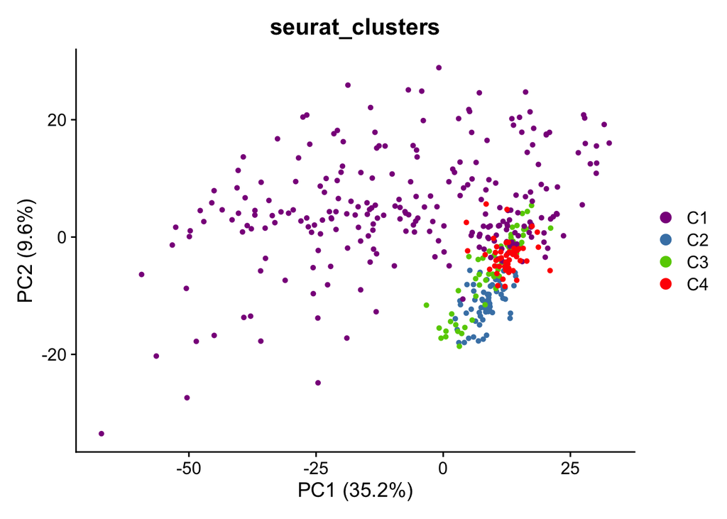

```r
# Handle cluster naming properly
# 妥善处理聚类命名
if (all(unique_clusters %in% c("0", "1", "2", "3"))) {
  sc_oo@meta.data$seurat_clusters <- factor(sc_oo@meta.data$seurat_clusters,
                                            levels = c("0", "1", "2", "3"),
                                            labels = c("C1", "C2", "C3", "C4"))
} else {
  # If clusters are already named C1, C2, etc., keep as is
  # 如果聚类已经是C1, C2等，保持不变
  if (all(grepl("^C[0-9]+$", unique_clusters))) {
    cat("Clusters already properly named. Keeping current names.\n")
  } else {
    # Otherwise, create proper labels
    # 否则，创建适当的标签
    all_levels <- sort(unique(as.character(sc_oo@meta.data$seurat_clusters)))
    cat("Found cluster levels:", paste(all_levels, collapse = ", "), "\n")

    if (all(grepl("^CC[0-9]+$", all_levels))) {
      # Extract numbers from CC1, CC2, etc. and create C1, C2, etc.
      # 从CC1, CC2等提取数字并创建C1, C2等
      labels <- paste0("C", sub("^CC", "", all_levels))
    } else {
      labels <- paste0("C", all_levels)
    }

    sc_oo@meta.data$seurat_clusters <- factor(sc_oo@meta.data$seurat_clusters,
                                            levels = all_levels,
                                            labels = labels)
  }
}

# Create a color palette that can handle any number of clusters
# 创建可以处理任意数量聚类的调色板
n_clusters <- length(unique(sc_oo@meta.data$seurat_clusters))
colors <- c("darkmagenta", "steelblue", "chartreuse3", "red", "purple", "orange", "brown", "pink", "cyan", "magenta")
cluster_colors <- colors[1:n_clusters]
if (length(cluster_colors) < n_clusters) {
  cluster_colors <- c(cluster_colors, rainbow(n_clusters - length(cluster_colors)))
}

# 画图
# draw
PCAPlot(sc_oo, group.by = "seurat_clusters") +
  scale_color_manual(values = cluster_colors,
                     na.value = "grey90",  # Color for NA values
                     drop = FALSE) +  # Keep all factor levels
  xlab(paste0("PC1 (", pc1.pv,")")) +
  ylab(paste0("PC2 (", pc2.pv,")"))
```

```r
# 保存到文件
# Save to file
ggsave("PCA_A_simplified.pdf", width = 6, height = 5)
```

### 7.2 画Fig. 3B Draw Fig. 3B

用Seurat自带的无监督聚类获得的seurat_clusters画图

Plotting the seurat_clusters obtained using Seurat’s built-in unsupervised clustering

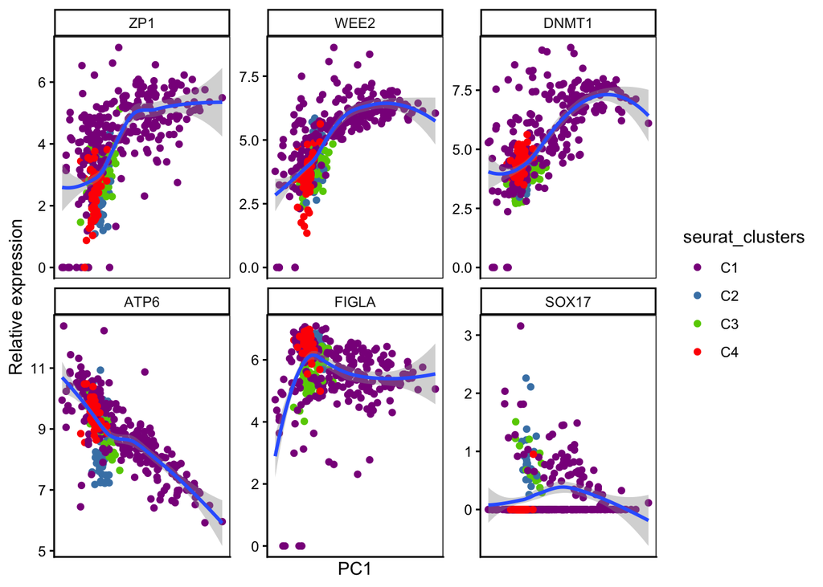

```r
markers <- c("ZP1", "WEE2", "DNMT1", "ATP6", "FIGLA", "SOX17")

# Get expression data for Seurat v5
# 为Seurat v5获取表达数据
if (packageVersion("Seurat") >= "5.0.0") {
  expr_data <- LayerData(sc_oo, assay = "RNA", layer = "data")
} else {
  expr_data <- GetAssayData(sc_oo, slot = "data")
}

# Prepare plot data
# 准备绘图数据
plot_data <- cbind(sc_oo@meta.data[,"seurat_clusters", drop = F],
                   PC1 = -pca.pv@cell.embeddings[,1],
                   expr_data[markers,] %>% t)

# Create color palette for this plot as well
# 为这张图也创建调色板
n_clusters_plot <- length(unique(plot_data$seurat_clusters))
colors_plot <- c("darkmagenta", "steelblue", "chartreuse3", "red", "purple", "orange", "brown", "pink", "cyan", "magenta")
cluster_colors_plot <- colors_plot[1:n_clusters_plot]
if (length(cluster_colors_plot) < n_clusters_plot) {
  cluster_colors_plot <- c(cluster_colors_plot, rainbow(n_clusters_plot - length(cluster_colors_plot)))
}

reshape2::melt(plot_data,
id.vars = c("seurat_clusters", "PC1")) %>%
  ggplot(mapping = aes(PC1, value)) +
  ylab("Relative expression") +
  geom_point(mapping = aes(color = seurat_clusters)) +
  geom_smooth() +
  scale_color_manual(values = cluster_colors_plot,
                     na.value = "grey90",  # Color for NA values
                     drop = FALSE) +  # Keep all factor levels
  facet_wrap(~variable, scales = "free_y") +
  theme_classic() +
  theme(panel.border = element_rect(fill = NA),
        axis.text.x = element_blank(),
        axis.ticks.x = element_blank())
```

```r
ggsave("PCA_B_simplified.pdf", width = 7, height = 4)
```

### 7.3 跟原文对比 Compare with the original text

1-s2.0-S0092867420300568-mmc2.xlsx的第二列是细胞所在的cluster，是原文采用的聚类方法获得的cluster信息，用它跟我们做的”Seurat自带的无监督聚类”的结果对比。

The second column of 1-s2.0-S0092867420300568-mmc2.xlsx indicates the cluster to which each cell belongs, representing the cluster information obtained by the clustering method used in the original text. This can be compared with the results of our “unsupervised clustering with Seurat’s built-in method”.

```r
meta_oo <- readxl::read_excel(path = "1-s2.0-S0092867420300568-mmc2.xlsx", sheet = 2)
dim(meta_oo)
```

```
## [1] 414   2
```

```r
# Match cells and handle NA values
# 匹配细胞并处理NA值
matched_idx <- match(colnames(sc_oo), meta_oo$cell)
sc_oo$subtype <- meta_oo$cluster[matched_idx]

# Check for NA values
# 检查NA值
na_count <- sum(is.na(sc_oo$subtype))
if (na_count > 0) {
  cat("Warning:", na_count, "cells could not be matched in meta_oo. These will be excluded from subtype analysis.\n")
}

table(sc_oo$subtype, sc_oo$seurat_clusters, useNA = "ifany")
```

```
##
##      C1 C2 C3 C4
##   C1 81 14 39 41
##   C2 34 49 13 10
##   C3 57  0  2  0
##   C4 74  0  0  0
```

用原文聚类获得的subtype画图

Plot the subtypes obtained from original text clustering

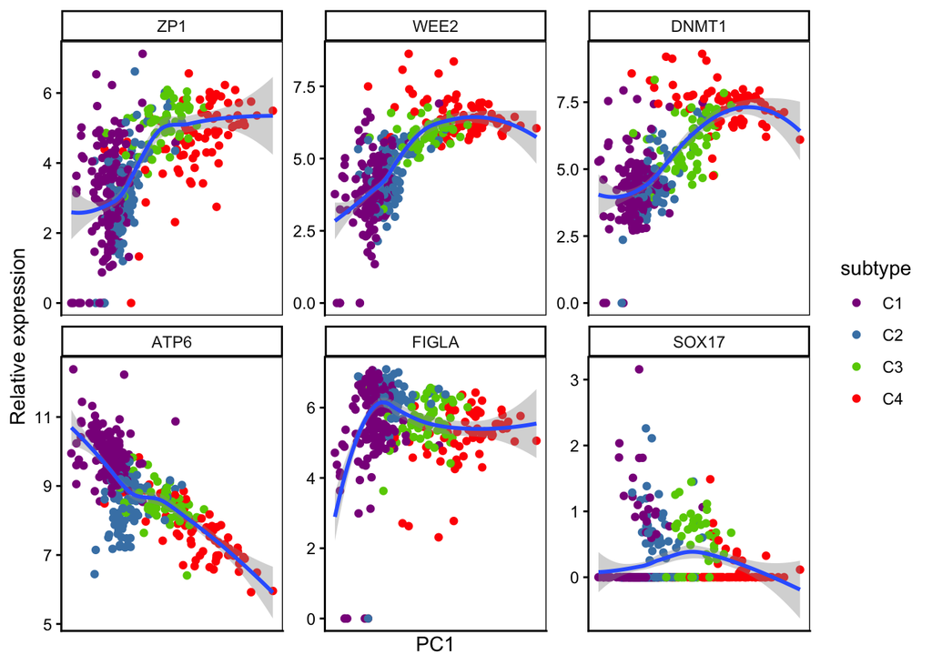

```r
# Prepare plot data for original subtypes
# 为原始subtype准备绘图数据
plot_data_ori <- cbind(sc_oo@meta.data[,"subtype", drop = F],
                     PC1 = -pca.pv@cell.embeddings[,1],
                     expr_data[markers,] %>% t)
plot_data_ori <- plot_data_ori[!is.na(plot_data_ori$subtype), ]

# Create color palette for original subtypes
# 为原始subtype创建调色板
n_clusters_subtype <- length(unique(plot_data_ori$subtype))
colors_subtype <- c("darkmagenta", "steelblue", "chartreuse3", "red", "purple", "orange", "brown", "pink", "cyan", "magenta")
cluster_colors_subtype <- colors_subtype[1:n_clusters_subtype]
if (length(cluster_colors_subtype) < n_clusters_subtype) {
  cluster_colors_subtype <- c(cluster_colors_subtype, rainbow(n_clusters_subtype - length(cluster_colors_subtype)))
}

reshape2::melt(plot_data_ori,
  id.vars = c("subtype", "PC1")) %>%
  ggplot(mapping = aes(PC1, value)) +
  ylab("Relative expression") +
  geom_point(mapping = aes(color = subtype)) +
  geom_smooth() +
  scale_color_manual(values = cluster_colors_subtype,
                     na.value = "grey90",  # Color for NA values
                     drop = FALSE) +  # Keep all factor levels
  facet_wrap(~variable, scales = "free_y") +
  theme_classic() +
  theme(panel.border = element_rect(fill = NA),
        axis.text.x = element_blank(),
        axis.ticks.x = element_blank())
```

```r
ggsave("PCA_B_ori_simplified.pdf", width = 7, height = 4)
```

## 8 主要改进 Key Improvements

1. **简化了数据处理流程**: 移除了复杂的 mnnCorrect 步骤，直接使用标准 Seurat v5 流程
2. **修正了PCA方差计算**: 使用正确的方差计算方法而非简单乘以100
3. **改进了聚类命名逻辑**: 更好地处理各种聚类命名格式
4. **动态颜色调色板**: 能够处理任意数量的聚类
5. **保持与v4版本兼容**: 简化后的流程更接近原始v4版本的结果
6. **Simplified data processing**: Removed complex mnnCorrect step, using standard Seurat v5 workflow
7. **Fixed PCA variance calculation**: Used proper variance calculation instead of simple multiplication by 100
8. **Improved cluster naming logic**: Better handling of various cluster naming formats
9. **Dynamic color palette**: Can handle any number of clusters
10. **Maintained compatibility with v4**: Simplified workflow is closer to original v4 results